# Housing Subsidy Algorithm for Emil City

Jasmine Siyu Wu

11/5/2021

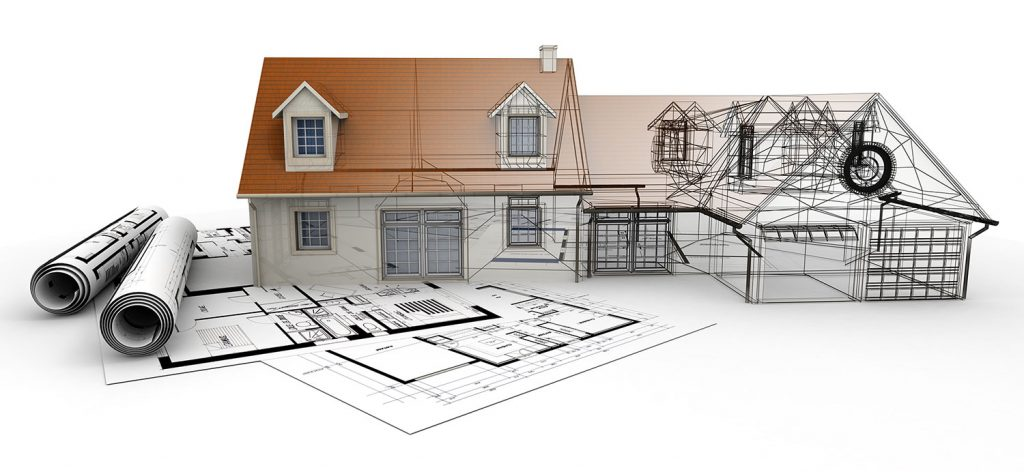

*Source: Cayman Homes Construction*

## 1. Introduction

Over the past twenty years, the Emil City Department of Housing and Community Development (HCD) has been running a home repair tax credit program. There is no doubt that home repair subsidy programs have considerable benefits to both homeowners and neighborhoods, yet this program has not been fully in use. The conversion rate of the eligible homeowners that have been reached out is inadequate, while the resources of outreach are limited. To more precisely target eligible homeowners who are more likely to take the credit, the HCD now wants to build a model based on the previous campaign information and results to better allocate the limited outreach resources to certain types of homeowners. In this analysis, we will further use the built model for a cost/benefit analysis to assist the agency’s decision-making.

```r
knitr::opts_chunk$set(echo=TRUE)
options(tigris_class = "sf")

options(scipen=10000000)

library(tidyverse)
library(kableExtra)
library(caret)
library(knitr)
library(pscl)
library(plotROC)
library(pROC)
library(lubridate)
library(gridExtra)
library(ggplot2)
library(grid)
library(ggpubr)



# functions and data directory
root.dir = "https://raw.githubusercontent.com/urbanSpatial/Public-Policy-Analytics-Landing/master/DATA/"
source("https://raw.githubusercontent.com/urbanSpatial/Public-Policy-Analytics-Landing/master/functions.r")

plotTheme <- function(base_size = 12) {
  theme(
    text = element_text( color = "black"),
    plot.title = element_text(size = 16,colour = "black"),
    plot.subtitle = element_text(face="italic"),
    plot.caption = element_text(size = 12, hjust=0),
    axis.ticks = element_blank(),
    panel.background = element_blank(),
    panel.grid.major = element_line("grey80", size = 0.1),
    panel.grid.minor = element_blank(),
    panel.border = element_rect(colour = "black", fill=NA, size=2),
    strip.background = element_rect(fill = "grey80", color = "white"),
    strip.text = element_text(size=12),
    axis.title = element_text(size=12),
    axis.text = element_text(size=10),
    plot.background = element_blank(),
    legend.background = element_blank(),
    legend.title = element_text(colour = "black", face = "italic"),
    legend.text = element_text(colour = "black", face = "italic"),
    strip.text.x = element_text(size = 14)
  )
}

palette5 <- c("#324376", "#586ba4", "#f5dd90", "#ee964b", "#f95738")
palette4 <- c("#324376", "#586ba4", "#ee964b", "#f95738")
palette2 <- c("#324376", "#f95738")



housingSub <- read.csv("C:/Users/11486/Box/2021Fall/CPLN592/Assignments/HW4/housingSubsidy.csv")
```

## 2. Exploratory Analysis

HCD provides a random record sample from the previous campaigns (N = 4,119), of which 451 (10.9%) homeowners took the credit and 3,668 (89.1%) did not take the credit. Each homeowner is attached with some variables, including numeric variables and categorical variables.

**Figure 2.1** shows the means of numeric features associated with the likelihood of taking the credit. As can be seen in the figures, the average age (`age`) of homeowners taking the credit is slightly higher than the homeowners not taking it. The average contacts for this campaign (`campaign`) are higher for homeowners not taking the credit, while the number of contacts before this campaign (`previous`) is higher for homeowners taking the credit. In terms of economic characteristics, two homeowner groups have similar mean consumer price index (`cons.price.idx`) and consumer confidence index (`cons.conf.idx`). Homeowners who took the credit show a lower average inflation rate (`inflation_rate`) and a negative unemployment rate (`unemploy_rate`), which is confusing. We need to examine the distribution of these numeric variables to better understand variances between two homeowner groups.

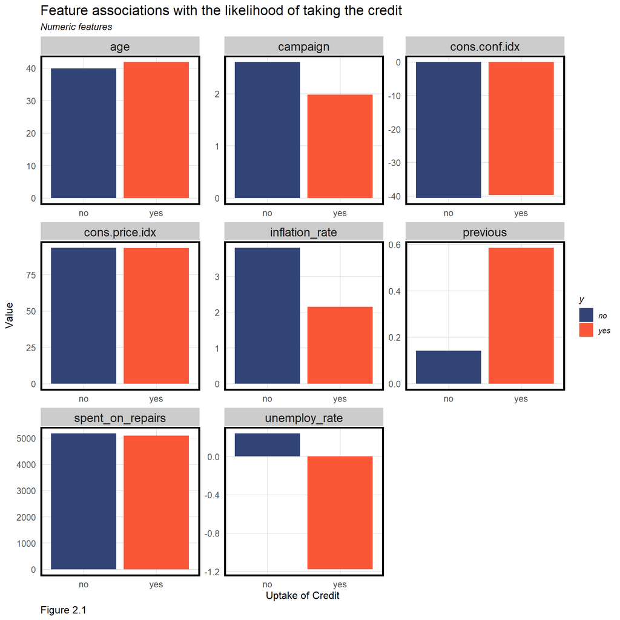

```r
housingSub %>%
  dplyr::select(y, age, campaign, previous, unemploy_rate, cons.price.idx, cons.conf.idx, inflation_rate, spent_on_repairs) %>%
  gather(Variable, value, -y) %>%
    ggplot(aes(y, value, fill=y)) +
      geom_bar(position = "dodge", stat = "summary", fun.y = "mean") +
      facet_wrap(~Variable, scales = "free") +
      scale_fill_manual(values = palette2) +
      labs(x="Uptake of Credit", y="Value",
           title = "Feature associations with the likelihood of taking the credit",
           subtitle = "Numeric features",
           caption = "Figure 2.1") +
  plotTheme()
```

As shown in **Figure 2.2**, the uptake of credit are associated with age groups.Homeowners taking the credit have a smaller share of the 30-to-50-years and larger share of the over-50-years. While Figure 2.1 shows merely no difference between average consumer price index (`cons.price.idx`) and consumer confidence index (`cons.conf.idx`), we can see more even distribution of these indexes in homeowners taking the credit. That is, for some sub-ranges of these indexes, homeowners taking the credit have a noticeable smaller presence than the other group, which may be a differentiator between them. As for the inflation rate (`inflation_rate`), homeowners not taking the credit have a peak of high inflation rates, echoing with their higher average inflation rate in Figure 2.1. Lastly, it is still hard to understand why negative values appear in the unemployment rate (`unemploy_rate`), so we will be cautious to use this variable as a predictor in the model.

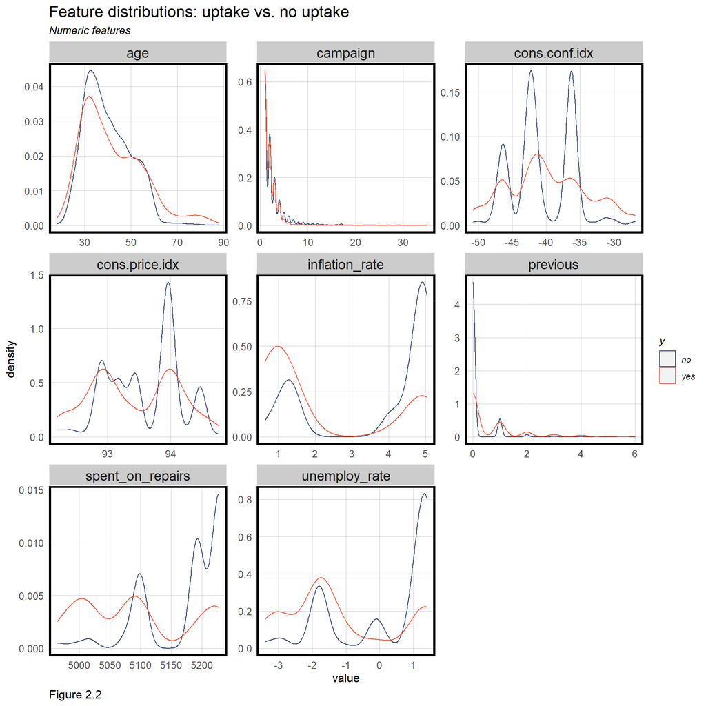

```r
housingSub %>%
    dplyr::select(y, age, campaign, previous, unemploy_rate, cons.price.idx, cons.conf.idx, inflation_rate, spent_on_repairs) %>%
    gather(Variable, value, -y) %>%
    ggplot() +
    geom_density(aes(value, color=y), fill = "transparent") +
    facet_wrap(~Variable, scales = "free") +
    scale_color_manual(values = palette2) +
    labs(title = "Feature distributions: uptake vs. no uptake",
         subtitle = "Numeric features",
         caption = "Figure 2.2") +
  plotTheme()
```

There are also some categorical features attached to homeowners. **Figure 2.3** shows the counts of each categorical feature by the uptake of the credit. There are no noticeable associations between whether or not taking the credit with the type of contact (`contact`) used to reach out homeowners, day of the week of last contact (`day_of_week`), marital status (`marital`), mortgage (`mortgage`), and tax lien (`taxLien`). However, we can see that homeowners’ uptake of the credit is related to some education levels (`education`), job types (`job`), months of the last contact (`month`), days after the last contact (`pdays`), and previous marketing campaign results (`poutcome`). These can be used as independent variables in the model.

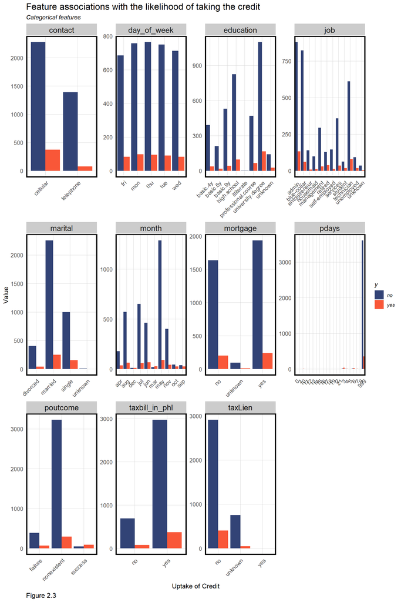

```r
housingSub %>%
    dplyr::select(y, job, marital, education, taxLien, mortgage, taxbill_in_phl,
                  contact, month, day_of_week, pdays, poutcome) %>%
    gather(Variable, value, -y) %>%
    count(Variable, value, y) %>%
      ggplot(., aes(value, n, fill = y)) +
        geom_bar(position = "dodge", stat="identity") +
        facet_wrap(~Variable, scales="free") +
        scale_fill_manual(values = palette2) +
        labs(x="Uptake of Credit", y="Value",
             title = "Feature associations with the likelihood of taking the credit",
             subtitle = "Categorical features",
             caption = "Figure 2.3") +
        theme(axis.text.x = element_text(angle = 45, hjust = 1)) +
  plotTheme()
```

## 3. Logistic Regression

In this analysis, we use logit regression to predict the binomial variable. Our dependent variable is `y_numeric`, of which 0 means “not taking the credit” and 1 means “taking the credit”. The data is split into 65/35 training/test set in this analysis, meaning that roughly 2680 records are used for training the logit model while the rest 1440 records are used to test the accuracy and generalizability of the model.

### 3.1. Kitchen Sink Model

The first model uses most of the original variables coming with the data. As the summary shows, its McFadden (pseudo-$R^{2}$) is 0.218, implying an undesired predicting power of the model.

```r
set.seed(1234)
trainIndex <- createDataPartition(y = paste(housingSub$y_numeric, housingSub$taxLien), p = .65,
                                  list = FALSE,
                                  times = 1)
housingSubTrain <- housingSub[ trainIndex,]
housingSubTest  <- housingSub[-trainIndex,]


housingSubModel <- glm(y_numeric ~ .,
                  data=housingSubTrain %>%
                    dplyr::select(-age, marital, -mortgage, -contact, -day_of_week, -pdays,
                                  -y, -unemploy_rate),
                  family="binomial" (link="logit"))


summary(housingSubModel)
```

```
##
## Call:
## glm(formula = y_numeric ~ ., family = binomial(link = "logit"),
##     data = housingSubTrain %>% dplyr::select(-age, marital, -mortgage,
##         -contact, -day_of_week, -pdays, -y, -unemploy_rate))
##
## Deviance Residuals:
##     Min       1Q   Median       3Q      Max
## -2.3482  -0.4043  -0.3257  -0.2574   2.8693
##
## Coefficients:
##                                   Estimate    Std. Error z value       Pr(>|z|)
## (Intercept)                   28.411368643  82.545716842   0.344         0.7307
## X                             -0.000004852   0.000059859  -0.081         0.9354
## jobblue-collar                -0.362778158   0.275850443  -1.315         0.1885
## jobentrepreneur               -0.258276866   0.460794927  -0.561         0.5751
## jobhousemaid                  -0.085410459   0.480059569  -0.178         0.8588
## jobmanagement                 -0.576836547   0.317889799  -1.815         0.0696
## jobretired                     0.154971510   0.322257935   0.481         0.6306
## jobself-employed              -1.294498119   0.535391152  -2.418         0.0156
## jobservices                   -0.179228605   0.288345664  -0.622         0.5342
## jobstudent                    -0.242369783   0.426233284  -0.569         0.5696
## jobtechnician                 -0.351796746   0.250496919  -1.404         0.1602
## jobunemployed                 -0.220820198   0.421756122  -0.524         0.6006
## jobunknown                    -0.638568095   0.890133886  -0.717         0.4731
## maritalmarried                 0.120239900   0.246273304   0.488         0.6254
## maritalsingle                  0.143130025   0.265553796   0.539         0.5899
## maritalunknown                 0.322516527   1.166650324   0.276         0.7822
## educationbasic.6y              0.266424709   0.400575621   0.665         0.5060
## educationbasic.9y              0.018756925   0.322914863   0.058         0.9537
## educationhigh.school          -0.188229823   0.313867496  -0.600         0.5487
## educationilliterate          -12.442059277 535.411360726  -0.023         0.9815
## educationprofessional.course   0.291592562   0.347694973   0.839         0.4017
## educationuniversity.degree     0.175941308   0.308378806   0.571         0.5683
## educationunknown               0.473563393   0.394602535   1.200         0.2301
## taxLienunknown                -0.041197238   0.218131655  -0.189         0.8502
## taxLienyes                    -9.619889276 535.411470395  -0.018         0.9857
## taxbill_in_phlyes              0.220811245   0.191610799   1.152         0.2492
## monthaug                      -0.157909353   0.363487147  -0.434         0.6640
## monthdec                       1.367644356   0.719075478   1.902         0.0572
```

[output cut: 54 more lines]

```
## poutcomesuccess              ***
## cons.price.idx
## cons.conf.idx
## inflation_rate
## spent_on_repairs
## ---
## Signif. codes:  0 '***' 0.001 '**' 0.01 '*' 0.05 '.' 0.1 ' ' 1
##
## (Dispersion parameter for binomial family taken to be 1)
##
##     Null deviance: 1854.0  on 2679  degrees of freedom
## Residual deviance: 1450.5  on 2637  degrees of freedom
## AIC: 1536.5
##
## Number of Fisher Scoring iterations: 12
```

```r
pR2(housingSubModel)
```

```
## fitting null model for pseudo-r2
```

```
##          llh      llhNull           G2     McFadden         r2ML         r2CU
## -725.2465766 -926.9872895  403.4814258    0.2176305    0.1397677    0.2799179
```

Using the first model to predict the test set, we see that most of the *negative events (0’s)* (not taking the credit) can be well predicted as the “hump” is around 0. However, only a small portion of *positive events (1’s)* (taking the credit) have probabilities close to 1, and the “hump” is far away from 1, in fact around 0. That is, this “kitchen sink” model has a weak predicting power of *positive events (0’s)*.

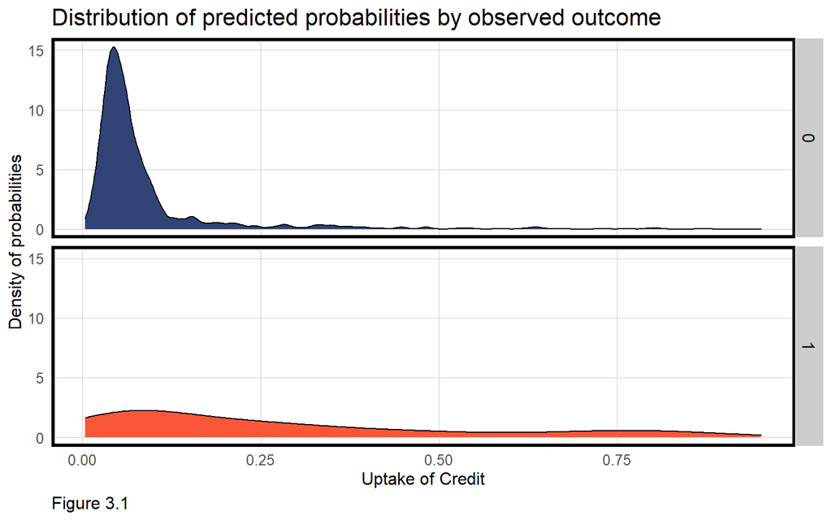

```r
testProbs <- data.frame(Outcome = as.factor(housingSubTest$y_numeric),
                        Probs = predict(housingSubModel, housingSubTest, type= "response"))

ggplot(testProbs, aes(x = Probs, fill = as.factor(Outcome))) +
  geom_density() +
  facet_grid(Outcome ~ .) +
  scale_fill_manual(values = palette2) +
  labs(x = "Uptake of Credit", y = "Density of probabilities",
       title = "Distribution of predicted probabilities by observed outcome",
       caption = "Figure 3.1") +
  theme(strip.text.x = element_text(size = 18),
        legend.position = "none") +
  plotTheme()
```

Besides McFadden (pseudo-$R^{2}$), Sensitivity and Specificity also measure the goodness of Fit of a logit model. As the summary below shows, the Sensitivity and Specificity of `housingSubModel` is 0.1975 and 0.9867, respectively. Therefore, only 19.75% of all positives (0’s) can be explained by our model, while 98.67% of all negatives (0’s) can be explained by the model.

```r
testProbs <-
  testProbs %>%
  mutate(predOutcome  = as.factor(ifelse(testProbs$Probs > 0.5 , 1, 0)))



caret::confusionMatrix(testProbs$predOutcome, testProbs$Outcome,
                       positive = "1")
```

```
## Confusion Matrix and Statistics
##
##           Reference
## Prediction    0    1
##          0 1265  126
##          1   17   31
##
##                Accuracy : 0.9006
##                  95% CI : (0.884, 0.9156)
##     No Information Rate : 0.8909
##     P-Value [Acc > NIR] : 0.1261
##
##                   Kappa : 0.2649
##
##  Mcnemar's Test P-Value : <0.0000000000000002
##
##             Sensitivity : 0.19745
##             Specificity : 0.98674
##          Pos Pred Value : 0.64583
##          Neg Pred Value : 0.90942
##              Prevalence : 0.10910
##          Detection Rate : 0.02154
##    Detection Prevalence : 0.03336
##       Balanced Accuracy : 0.59210
##
##        'Positive' Class : 1
##
```

To further test the generalizability of the first model, we run a 100 k-fold cross validation and output predicted probabilities. Since the dependent variable in the cross-validation is `y` instead of `y_numeric`, the Sensitivity and Specificity are reversed. The results show that the generalized model has a Sensitivity of 0.985 and a Specificity of 0.221. That is, the first model in general can explain 22.1% of all positives (taking the credit) and 98.5% of all negatives (not taking the credit). The area under the ROC curve (known as AUC) is 0.76, suggesting the model has some substantial predicting power.

```r
ctrl <- trainControl(method = "cv", number = 100, classProbs=TRUE, summaryFunction=twoClassSummary)

cvFit_1 <- train(y ~ .,
                  data=housingSub %>%
                    dplyr::select(-age, marital, -mortgage, -contact, -day_of_week, -pdays, -unemploy_rate,
                                  -y_numeric),
                method="glm", family="binomial",
                metric="ROC", trControl = ctrl)

cvFit_1
```

```
## Generalized Linear Model
##
## 4119 samples
##   14 predictor
##    2 classes: 'no', 'yes'
##
## No pre-processing
## Resampling: Cross-Validated (100 fold)
## Summary of sample sizes: 4079, 4077, 4079, 4078, 4079, 4078, ...
## Resampling results:
##
##   ROC        Sens      Spec
##   0.7608405  0.984985  0.221
```

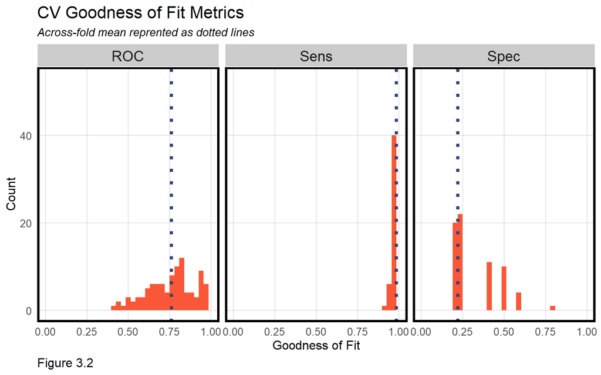

```r
dplyr::select(cvFit_1$resample, -Resample) %>%
  gather(metric, value) %>%
  left_join(gather(cvFit_1$results[2:4], metric, mean)) %>%
  ggplot(aes(value)) +
    geom_histogram(bins=35, fill = palette2[2]) +
    facet_wrap(~metric) +
    geom_vline(aes(xintercept = mean), colour = palette2[1], linetype = 3, size = 1.5) +
    scale_x_continuous(limits = c(0, 1)) +
    labs(x="Goodness of Fit", y="Count", title="CV Goodness of Fit Metrics",
         subtitle = "Across-fold mean reprented as dotted lines",
         caption = "Figure 3.2") +
  plotTheme()
```

### 3.2. New Model with Engineered Features

To improve the “kitchen sink” model, this section engineers new features based on the observations in **2. Exploratory Analysis**.

Firstly, some numeric features are re-classfied as categorical features. `previous_bi` is a binary variable developed upon `pdays`: 1 means the homeowner has been contacted before, and 0 mean not. `age_group` is a multi-categorical variable derived from `age`: under 30 years old are `YoungAdult`, between 30 and 50 years old are `MiddleAge`, and over 50 years old are `OldAdult`. `retired_bi` is a dummy variable derived from `job`: 1 means the individual is retired, and 0 means not.

Secondly, some numeric variables are transformed in the model, such as `log(spent_on_repairs+1)`, `log(inflation_rate)`, and `I(abs(unemploy_rate)^-1)`. Their associations with the dependent variable increase after transformations.

In comparison to the first model, the new engineered model has a similar McFadden (pseudo-$R^{2}$), 0.2135. As *Figure 3.3* shows, this new model has a few more predicted probabilities close to 1, suggesting a slightly better predicting power of positives.

```r
housingSub <- housingSub %>%
  mutate(previous_bi = ifelse(pdays < 999, "1", "0"),
         highschool = case_when(education %in% c("basic.4y", "basic.6y", "basic.9y", "illiterate") ~ "Yes",
                                education %in% c("high.school", "professional.course", "university.degree") ~ "No",
                                education == "unknown" ~ "unknown"),
         season = case_when(month %in% c("may", "jun", "jul", "aug")  ~ "Summer",
                            month %in% c("mar", "apr", "sep", "oct", "nov", "dec")  ~ "Other"),
         age_group = case_when(age < 30 ~ "YoungAdult",
                               age >= 30 & age < 50  ~ "MiddleAge",
                               age >= 50  ~ "OldAdult"),
         p_success = ifelse(poutcome == "success", "Yes", "No"),
         retired_bi = ifelse(job == "retired", "Yes", "No"))


set.seed(1234)
trainIndex <- createDataPartition(housingSub$y_numeric, p = .65,
                                  list = FALSE,
                                  times = 1)
housingSubTrain_2 <- housingSub[ trainIndex,]
housingSubTest_2  <- housingSub[-trainIndex,]



housingSubModel_2 <- glm(y_numeric ~ marital + education + month + previous_bi + age_group + previous +
                           log(spent_on_repairs+1) + log(inflation_rate) + retired_bi + I(abs(unemploy_rate)^-1),
                         data=housingSubTrain_2 %>%
                           dplyr::select(-X, -mortgage, -age, -day_of_week, -pdays, -contact,
                                         -y, -taxLien, -cons.price.idx, -cons.conf.idx,
                                         -job, -taxbill_in_phl, -highschool, -poutcome, -season,
                                         -campaign, -p_success),
                  family="binomial" (link="logit"))


summary(housingSubModel_2)
```

```
##
## Call:
## glm(formula = y_numeric ~ marital + education + month + previous_bi +
##     age_group + previous + log(spent_on_repairs + 1) + log(inflation_rate) +
##     retired_bi + I(abs(unemploy_rate)^-1), family = binomial(link = "logit"),
##     data = housingSubTrain_2 %>% dplyr::select(-X, -mortgage,
##         -age, -day_of_week, -pdays, -contact, -y, -taxLien, -cons.price.idx,
##         -cons.conf.idx, -job, -taxbill_in_phl, -highschool, -poutcome,
##         -season, -campaign, -p_success))
##
## Deviance Residuals:
##     Min       1Q   Median       3Q      Max
## -2.2196  -0.4047  -0.3252  -0.2457   2.7599
##
## Coefficients:
##                               Estimate Std. Error z value     Pr(>|z|)
## (Intercept)                  246.15594  139.22235   1.768      0.07705 .
## maritalmarried                 0.11129    0.25578   0.435      0.66348
## maritalsingle                  0.25856    0.28394   0.911      0.36250
## maritalunknown               -11.49680  382.82107  -0.030      0.97604
## educationbasic.6y              0.46395    0.44155   1.051      0.29338
## educationbasic.9y              0.29524    0.34349   0.860      0.39006
## educationhigh.school           0.30121    0.31199   0.965      0.33433
## educationilliterate          -13.32219  882.74352  -0.015      0.98796
## educationprofessional.course   0.59455    0.32344   1.838      0.06603 .
## educationuniversity.degree     0.59579    0.29518   2.018      0.04355 *
## educationunknown               0.57813    0.39272   1.472      0.14099
## monthaug                       0.25265    0.30386   0.831      0.40571
## monthdec                       1.45122    0.63016   2.303      0.02128 *
## monthjul                       0.29564    0.32434   0.911      0.36203
## monthjun                       0.65640    0.30852   2.128      0.03337 *
## monthmar                       1.39967    0.45695   3.063      0.00219 **
## monthmay                      -0.50737    0.27427  -1.850      0.06432 .
## monthnov                      -0.15762    0.45699  -0.345      0.73016
## monthoct                      -0.18496    0.42829  -0.432      0.66585
## monthsep                      -0.20906    0.46341  -0.451      0.65189
## previous_bi1                   1.61277    0.28806   5.599 0.0000000216 ***
## age_groupOldAdult              0.25526    0.19603   1.302      0.19286
## age_groupYoungAdult           -0.11862    0.22167  -0.535      0.59257
## previous                      -0.10194    0.11835  -0.861      0.38903
## log(spent_on_repairs + 1)    -29.09448   16.32146  -1.783      0.07465 .
## log(inflation_rate)           -0.62457    0.33674  -1.855      0.06363 .
## retired_biYes                  0.46596    0.30878   1.509      0.13129
## I(abs(unemploy_rate)^-1)       0.05019    0.05266   0.953      0.34060
## ---
## Signif. codes:  0 '***' 0.001 '**' 0.01 '*' 0.05 '.' 0.1 ' ' 1
##
## (Dispersion parameter for binomial family taken to be 1)
##
##     Null deviance: 1849.3  on 2677  degrees of freedom
## Residual deviance: 1454.4  on 2650  degrees of freedom
## AIC: 1510.4
##
## Number of Fisher Scoring iterations: 13
```

```r
pR2(housingSubModel_2)
```

```
## fitting null model for pseudo-r2
```

```
##          llh      llhNull           G2     McFadden         r2ML         r2CU
## -727.2242982 -924.6599329  394.8712694    0.2135224    0.1370945    0.2749011
```

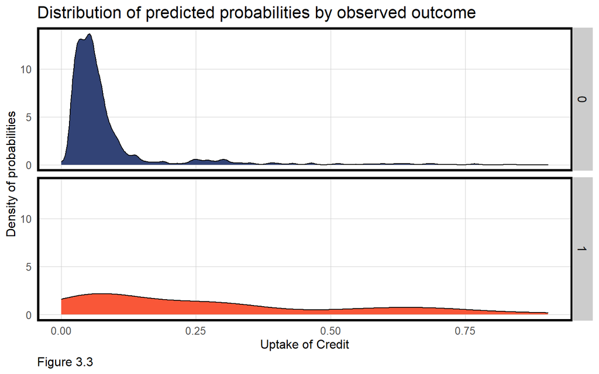

```r
testProbs_2 <- data.frame(Outcome = as.factor(housingSubTest_2$y_numeric),
                        Probs = predict(housingSubModel_2, housingSubTest_2, type= "response"))

ggplot(testProbs_2, aes(x = Probs, fill = as.factor(Outcome))) +
  geom_density() +
  facet_grid(Outcome ~ .) +
  scale_fill_manual(values = palette2) +
  labs(x = "Uptake of Credit", y = "Density of probabilities",
       title = "Distribution of predicted probabilities by observed outcome",
       caption = "Figure 3.3") +
  theme(strip.text.x = element_text(size = 18),
        legend.position = "none")+
  plotTheme()
```

As the confusion matrix shows, the new model has a Sensitivity of 0.241 and a Specificity of 0.982. Comparing to the first model’s 0.198 and 0.987, respectively, this new model can explain additional 4% of all positives while losing 0.5% predicting power of negatives. This shows the tradeoffs between predicting positives and negatives.

```r
#set up threshold
testProbs_2 <-
  testProbs_2 %>%
  mutate(predOutcome = as.factor(ifelse(testProbs_2$Probs > 0.5 , 1, 0)))


#confusion matrix
caret::confusionMatrix(testProbs_2$predOutcome, testProbs_2$Outcome,
                       positive = "1")
```

```
## Confusion Matrix and Statistics
##
##           Reference
## Prediction    0    1
##          0 1260  120
##          1   23   38
##
##                Accuracy : 0.9008
##                  95% CI : (0.8842, 0.9157)
##     No Information Rate : 0.8904
##     P-Value [Acc > NIR] : 0.1096
##
##                   Kappa : 0.3046
##
##  Mcnemar's Test P-Value : 0.0000000000000009914
##
##             Sensitivity : 0.24051
##             Specificity : 0.98207
##          Pos Pred Value : 0.62295
##          Neg Pred Value : 0.91304
##              Prevalence : 0.10965
##          Detection Rate : 0.02637
##    Detection Prevalence : 0.04233
##       Balanced Accuracy : 0.61129
##
##        'Positive' Class : 1
##
```

**Figure 3.4** shows the ROC curve of the new logit model, whose area under the curve is 0.7639, slightly higher than the first model’s 0.7608. Conducting the 100-fold cross-validation for the new model, we can see the generalized model reside around an ROC of 0.7773, a Sensitivity of 0.983, and a Specificity of 0.23. Again, the Sensitivity and Specificity are swapped in the cross-validation. This means the new model can explain 1% more positives (taking the credit) than the first model after generalization.

```r
auc(testProbs_2$Outcome, testProbs_2$Probs)
```

```
## Area under the curve: 0.7639
```

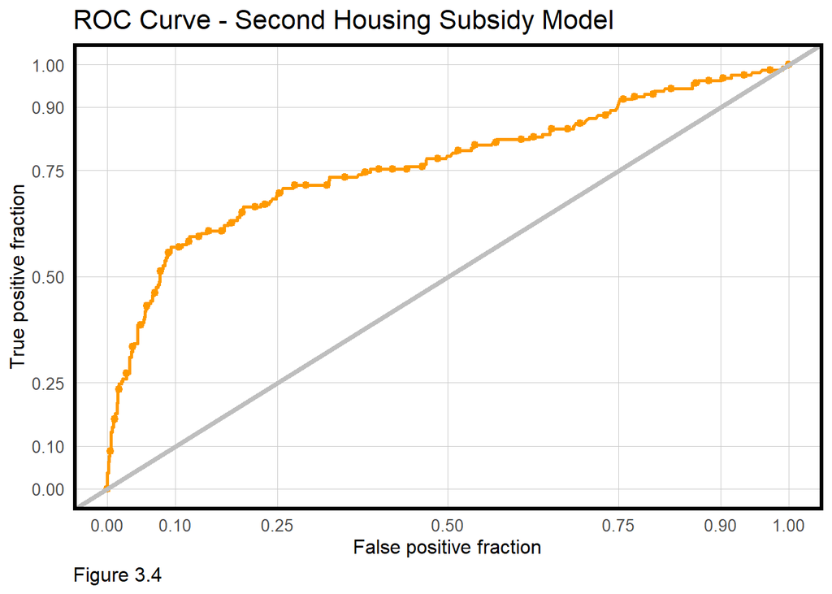

```r
ggplot(testProbs_2, aes(d = as.numeric(testProbs_2$Outcome), m = Probs)) +
  geom_roc(n.cuts = 50, labels = FALSE, colour = "#FE9900") +
  style_roc(theme = theme_grey) +
  geom_abline(slope = 1, intercept = 0, size = 1.5, color = 'grey') +
  labs(title = "ROC Curve - Second Housing Subsidy Model",
       caption = "Figure 3.4") +
  plotTheme()
```

```r
ctrl <- trainControl(method = "cv", number = 100, classProbs=TRUE, summaryFunction=twoClassSummary)

cvFit <- train(y ~ marital + education + month + previous_bi + age_group + previous +
                   log(spent_on_repairs+1) + log(inflation_rate) + retired_bi + I(abs(unemploy_rate)^-1),
                  data=housingSub %>%
                    dplyr::select(-X, -mortgage, -age, -day_of_week, -pdays, -contact,
                                  -taxLien, -cons.price.idx, -cons.conf.idx,
                                  -job, -taxbill_in_phl, -highschool, -poutcome, -season,
                                  -campaign, -p_success,
                                  -y_numeric),
                method="glm", family="binomial",
                metric="ROC", trControl = ctrl)

cvFit
```

```
## Generalized Linear Model
##
## 4119 samples
##   10 predictor
##    2 classes: 'no', 'yes'
##
## No pre-processing
## Resampling: Cross-Validated (100 fold)
## Summary of sample sizes: 4079, 4077, 4077, 4077, 4078, 4077, ...
## Resampling results:
##
##   ROC        Sens       Spec
##   0.7772845  0.9831456  0.23
```

**Figure 3.5** shows the distribution of cross-validation’s goodness of fit metrics. They show roughly the same pattern as the first model’s metrics do (see Figure 3.2).

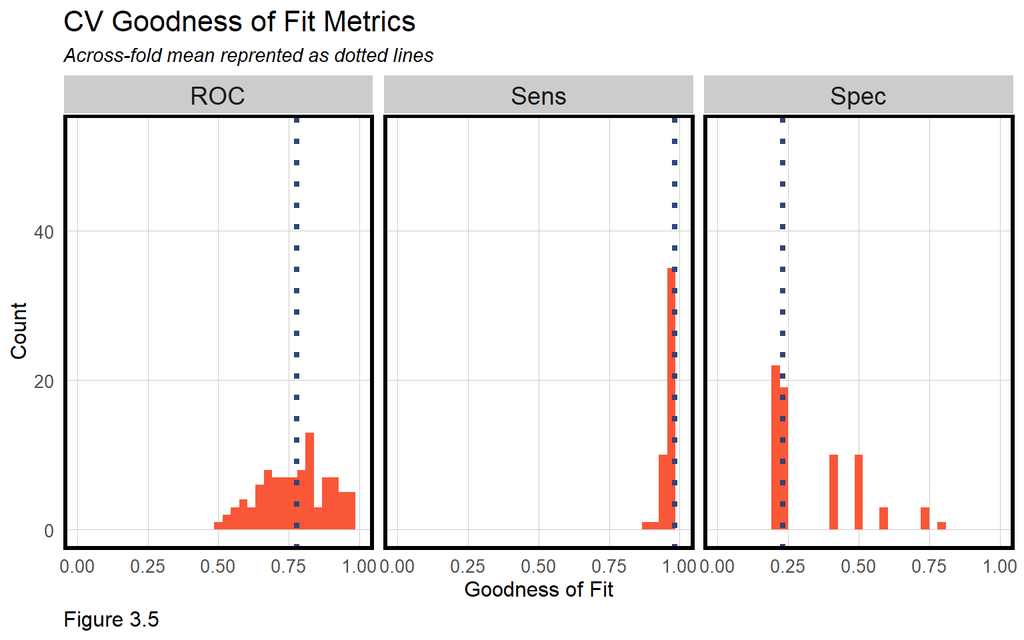

```r
dplyr::select(cvFit$resample, -Resample) %>%
  gather(metric, value) %>%
  left_join(gather(cvFit$results[2:4], metric, mean)) %>%
  ggplot(aes(value)) +
    geom_histogram(bins=35, fill = palette2[2]) +
    facet_wrap(~metric) +
    geom_vline(aes(xintercept = mean), colour = palette2[1], linetype = 3, size = 1.5) +
    scale_x_continuous(limits = c(0, 1)) +
    labs(x="Goodness of Fit", y="Count", title="CV Goodness of Fit Metrics",
         subtitle = "Across-fold mean reprented as dotted lines",
         caption = "Figure 3.5") +
  plotTheme()
```

## 4. Cost/Benefit Analysis

Based on the second model, we will conduct a cost/benefit analysis for Emil City’s housing tax credit program considering marketing costs, individual benefits, and social benefits. Some assumptions of costs and benefits from the HCD are:

- The marketing costs **$2,850** per homeowner for staff and resources to facilitate mailers, phone calls, and information/counselling sessions.
- The credit costs **$5,000** per homeowner which can be used toward home improvement.
- Each house after taking the credit will be sold with a **$10,000** premium.
- Each house after taking the credit will bring an aggregate premium of **$56,000** for the surrounding houses.

Given the assumptions above, we formulate the revenues and uptake of credits for each confusion metric:

**False negative (FN) revenue*** : predicted incorrectly homeowner would not take the credit

- `actualCredit` = Count * 0
- `Revenue` = $0

**False positive (FP) revenue** : predicted incorrectly homeowner would take the credit

- `actualCredit` = Count * 0
- `Revenue` = ($0 - $2850) * Count

**True negative (TN) revenue** : predicted correctly homeowner would not take the credit

- `actualCredit` = Count * 0
- `Revenue` = $0

**True positive (TP) revenue**** : predicted correctly homeowner would take the credit

* Although these homeowners took the housing tax credit, yet their decisions were not related to the marketing campaign. We zero out this category, assuming the cost/benefit and credit of this are 0.

** We assume that 25% of contacted eligible homeowners take the credit, and the remainder (75%) received the marketing allocation but do not take the credit.

Applying the above formulas to each confusion metric, we can calculate the total revenue of each category (see Table 4.1). In the test set (n = 1,441), 38 are correctly predicted to take the credit (`True_Positive`), generating a total revenue of $471,200. Meanwhile, 23 are incorrectly predicted to take the credit (`False_Positive`), costing $65,550 in total. The rest two categories have no cost and benefit. Note, all of these predictions are under the default threshold of 0.50.

```r
cost_benefit_table <-
   testProbs_2 %>%
      count(predOutcome, Outcome) %>%
      summarize(True_Negative = sum(n[predOutcome==0 & Outcome==0]),
                True_Positive = sum(n[predOutcome==1 & Outcome==1]),
                False_Negative = sum(n[predOutcome==0 & Outcome==1]),
                False_Positive = sum(n[predOutcome==1 & Outcome==0])) %>%
       gather(Variable, Count) %>%
       mutate(Revenue =
               ifelse(Variable == "True_Negative", 0 * Count,
               ifelse(Variable == "True_Positive", ((-2850) * (Count * .75)) + ((56000+10000-2850-5000) * (Count * .25)),
               ifelse(Variable == "False_Negative", 0 * Count,  # zero out this category
               ifelse(Variable == "False_Positive", (-2850) * Count, 0))))) %>%
    bind_cols(data.frame(Description = c(
              "We correctly predicted no uptake of credit",
              "We correctly predicted an uptake of credit",
              "We predicted no uptake but houseowner took the credit",
              "We predicted an uptake but houseowner did not take the credit")))

kable(cost_benefit_table,
       caption = "Table 4.1 Cost/Benefit Table") %>% kable_styling()
```

Table 4.1 Cost/Benefit Table

| Variable | Count | Revenue | Description |
| --- | --- | --- | --- |
| True_Negative | 1260 | 0 | We correctly predicted no uptake of credit |
| True_Positive | 38 | 471200 | We correctly predicted an uptake of credit |
| False_Negative | 120 | 0 | We predicted no uptake but houseowner took the credit |
| False_Positive | 23 | -65550 | We predicted an uptake but houseowner did not take the credit |

## 5. Optimizing Thresholds

The last step to tuning our model is to optimize the threshold of our logit model. **Figure 5.1** shows the total revenue and total credits of each confusion metric for each threshold. For **true positives** , total revenue and total credits decrease as the threshold increases. Also, the cost of **false positives** decreases as the threshold increases. This is because we cannot predict the uptake of credit well at high thresholds. Therefore, the maximum total revenue should be attained at a lower threshold, where the model can predict more correct uptake of credit.

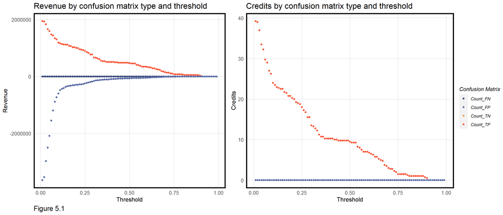

```r
whichThreshold <- iterateThresholds(testProbs_2, observedClass = Outcome, predictedProbs = Probs)

whichThreshold <-
  whichThreshold %>%
    dplyr::select(starts_with("Count"), Threshold) %>%
    gather(Variable, Count, -Threshold) %>%
    mutate(Revenue = case_when(Variable == "Count_TN" ~ 0 * Count,
                               Variable == "Count_TP" ~ (-2850) * Count * .75 + (56000+10000-2850-5000) * Count * .25,
                               Variable == "Count_FN" ~ 0 * Count,  # zero out this category
                               Variable == "Count_FP" ~ (-2850) * Count),
           actualCredit = ifelse(Variable == "Count_TP", (Count * .25), 0))


ggarrange(ncol=2,
  whichThreshold %>%
    ggplot(.,aes(Threshold, Revenue, colour = Variable)) +
    geom_point() +
    scale_colour_manual(values = palette4) +    #5,
    labs(title = "Revenue by confusion matrix type and threshold",
         y = "Revenue",
         caption = "Figure 5.1") +
    plotTheme() + theme(plot.caption = element_text(size = 14, hjust=0)) +
    guides(colour=guide_legend(title = "Confusion Matrix")),

  whichThreshold %>%
    ggplot(.,aes(Threshold, actualCredit, colour = Variable)) +
    geom_point() +
    scale_colour_manual(values = palette4) +    #5,
    labs(title = "Credits by confusion matrix type and threshold",
         y = "Credits",
         caption = " ") +
    plotTheme() + theme(plot.caption = element_text(size = 14, hjust=0)) +
    guides(colour=guide_legend(title = "Confusion Matrix")),
  common.legend = TRUE, legend="right")
```

Summing revenues and credits up of all confusion metrics, we are able to find the optimal threshold, where the total revenue of the housing tax credit campaign program reaches the highest value. As the left plot of **Figure 5.2** shows, the total revenue has its peak around the 15% threshold. That means, when the model classify all predicted possibilities over 0.15 as “taking the credit”, the HCD is likely to have the highest gaining from the campaign. Before a certain threshold (around 0.06), the total revenue is negative. After the optimal threshold, the total revenue decreases and approaches $0. The right plot echos the right side of Figure 5.1, of which only **true positives** are counted as total credits and decrease when the threshold increases. Its peak is around 0.01, meaning that only when the model classify everything as “taking the credit”, it can capture all positives (taking credits) in the real life.

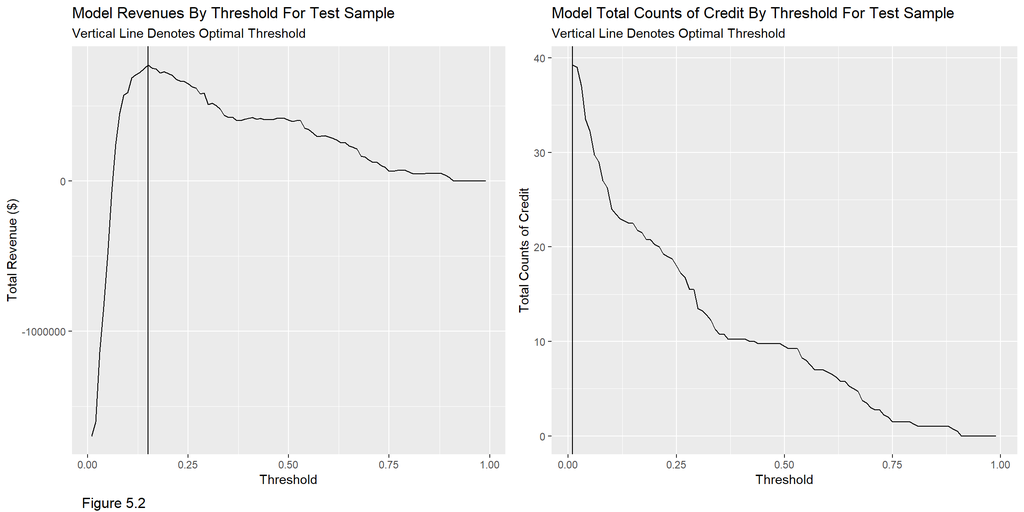

```r
whichThreshold_revenue <- whichThreshold %>%
    group_by(Threshold) %>%
    summarize(Revenue = sum(Revenue),
              Total_Credits = sum(actualCredit),
              Actual_Credit_Rate = sum(actualCredit) / sum(Count))

grid.arrange(ncol=2,
  ggplot(whichThreshold_revenue)+
    geom_line(aes(x = Threshold, y = Revenue))+
    geom_vline(xintercept =  pull(arrange(whichThreshold_revenue, -Revenue)[1,1]))+
      labs(title = "Model Revenues By Threshold For Test Sample",
           subtitle = "Vertical Line Denotes Optimal Threshold",
           y="Total Revenue ($)"),

  ggplot(whichThreshold_revenue)+
    geom_line(aes(x = Threshold, y = Total_Credits))+
    geom_vline(xintercept =  pull(arrange(whichThreshold_revenue, -Total_Credits)[1,1]))+
      labs(title = "Model Total Counts of Credit By Threshold For Test Sample",
           subtitle = "Vertical Line Denotes Optimal Threshold",
           y="Total Counts of Credit"),
  bottom = textGrob("Figure 5.2", x = 0.08, y = 0.5, just = "left"))
```

```r
#0.15 and 0.93-0.99
```

**Table 5.1** compares the 50% threshold and the optimal threshold (15%). Of all 1,441 homeowners in the test set, the optimal threshold can correctly predict 22.5 homeowners taking the credits and result in $771,150 revenue. The 50% threshold can only correctly predict 9.5 homeowners taking the credits and result in $405,650 revenue. Once again, this shows that when setting the threshold low, this model can predict more correct credits being taken in reality, which lead to more revenues for homeowners and society.

```r
subset(whichThreshold_revenue, Threshold == 0.15 | Threshold == 0.5) %>%
  mutate(Model = c("Optimal Threshold", "50% Threshold")) %>%
  select(Model, Threshold, Revenue, Total_Credits) %>%
  kable(align='c', caption="Table 5.1 Total Revenue and Total Credits by Threshold") %>%
  kable_styling()
```

Table 5.1 Total Revenue and Total Credits by Threshold

| Model | Threshold | Revenue | Total_Credits |
| --- | --- | --- | --- |
| Optimal Threshold | 0.15 | 771150 | 22.5 |
| 50% Threshold | 0.50 | 405650 | 9.5 |

```r
#0.16 and 0.91-0.99
```

## 6. Conclusion

In conclusion, the engineered model should be put into production although with a low Sensitivity. It can only explain less than 25% of all uptakes of the housing tax credit in the past. The unexplained portion (75%) of people who take credits will cause the waste of marketing resources. However, this model is still instructive if setting a low threshold, when it generates considerable total revenues. This is a significant gaining for residents and the city.

If we can improve the model’s predicting power of positives (taking the credit), we can ensure better use of HCD’s budget and further increase the total revenue. Several methods can be utilized to make the model better. First of all, the agency can collect more important features of houses and homeowners, such as house size, house age, and renovation rate of the neighborhood. Secondly, we can use a larger sample or simulate positives to increase the share of positives in the dataset. Lastly, we can attempt new prediction models, such as neural networks. To increase the response rate, the HCD staff can change the contact time. For instance, phone calls are more likely to be picked up on weekends. Learning the homeowners who took the credit in the past gives us an opportunity to improve targeted marketing strategies.